# R Notebook for Lake Biwa GLS analysis, revised for Fungal Ecology revision

Maiko Kagami and Takeshi Miki

2025.05.28

## [0] Checking system and loading packages into library

```r
Sys.setenv(LANGUAGE="en") #Setting the message language as English
version
```

```
               _
platform       x86_64-w64-mingw32
arch           x86_64
os             mingw32
crt            ucrt
system         x86_64, mingw32
status
major          4
minor          4.0
year           2024
month          04
day            24
svn rev        86474
language       R
version.string R version 4.4.0 (2024-04-24 ucrt)
nickname       Puppy Cup
```

```r
library(nlme) #for GLS
library(tseries) #for ADF test
library(MuMIn) #for model comparison
library(gt) #for drawing tables
library(gtsummary) #for generating tables
```

## [1] References

- Regression analysis on time series data (in Japanese): https://logics-of-blue.com/time-series-regression/
- Cohen’s f^2 (effect size) for each variable in multiple regression (but it does not work directly for gls model if we simply use the residuals for pseudo R-squared) https://www.frontiersin.org/journals/psychology/articles/10.3389/fpsyg.2012.00111/full

$$f^2 = \frac{R_{AB}^2 - R_A^2} {1 - R_{AB}^2}$$

- McFadden’s R²: pseudo R-squared value using log-likelihood

$$R_{Mc}^2 = 1 - \frac{\ln L_1} {\ln L_0}$$

- Combining two:
  $$f^2 = \frac {R_{Mc}^2(AB) - R_{Mc}^2(A)} {1 - R_{Mc}^2(AB)}
  = \frac{1 - \frac{\ln L_{AB}} {\ln L_0} - 1 + \frac{\ln L_{A}} {\ln L_0}
  } {\frac{\ln L_{AB}} {\ln L_0}}
  = \frac{\ln L_A} {\ln L_{AB}} - 1$$

## [2] Analysis for the data @ 0-10m

### [2.1] Data loading

```r
#0-10m
data10m_original <- read.csv("glm_2015_2020_0-10m.csv")
data10m_original
```

| id | year | month | density_M | density_S | prevalence_M | prevalence_S | water_temp | DIN | PO4 | NH4 | NO3 |
| --- | --- | --- | --- | --- | --- | --- | --- | --- | --- | --- | --- |
| 1 | 2015 | Apr | 0 | 0 | 0.00 | 0.00 | 9.3 | 0.184 | 0.000 | 0.184 | 0.160 |
| 2 | 2015 | May | 0 | 1147 | 0.00 | 1.10 | 15.9 | 0.164 | 0.000 | 0.164 | 0.150 |
| 3 | 2015 | Jun | 0 | 11305 | 0.00 | 19.02 | 20.0 | 0.089 | 0.000 | 0.089 | 0.080 |
| 4 | 2015 | Jul | 0 | 4621 | 0.00 | 20.00 | 23.0 | 0.042 | 0.001 | 0.042 | 0.040 |
| 5 | 2015 | Aug | 0 | 99 | 46.15 | 30.70 | 26.0 | 0.045 | 0.001 | 0.045 | 0.040 |
| 6 | 2015 | Sep | 0 | 25 | 0.00 | 11.11 | 23.8 | 0.000 | 0.012 | 0.000 | 0.000 |
| 7 | 2015 | Oct | 0 | 239 | 0.00 | 27.62 | 20.1 | 0.015 | 0.002 | 0.015 | 0.015 |
| 8 | 2015 | Nov | 0 | 0 | 0.00 | 0.00 | 16.6 | 0.046 | 0.000 | 0.046 | 0.030 |
| 9 | 2015 | Dec | 14 | 0 | 0.00 | 0.00 | 12.9 | 0.071 | 0.003 | 0.071 | 0.065 |
| 10 | 2016 | Jan | 28 | 0 | 0.00 | 0.00 | 10.5 | 0.130 | 0.000 | 0.130 | 0.110 |

[output cut: 61 more lines]

### [2.2] Data preprocessing

```r
#copy the original data
data10m <- data10m_original
#scaling for explanatory variables only
data10m[6:12] <- lapply(data10m_original[6:12], function(x) c(scale(x)))

#cutting the final data
data10m <- data10m[-length(data10m[, 1]), 1:12]
```

### [2.3] Checking the existence of unit root for the time series data

#### [2.3.1] ADF tests for predictor variables

```r
adf.test(data10m$density_M)
```

```
    Augmented Dickey-Fuller Test

data:  data10m$density_M
Dickey-Fuller = -2.6694, Lag order = 4, p-value = 0.303
alternative hypothesis: stationary
```

→ ADF test for M.hardyi, telling that it cannot reject the presence of the unit root

```r
adf.test(data10m$density_M[-c(1:8)])
```

```
    Augmented Dickey-Fuller Test

data:  data10m$density_M[-c(1:8)]
Dickey-Fuller = -3.1086, Lag order = 3, p-value = 0.1262
alternative hypothesis: stationary
```

→ Even after removing the series of zero values, it cannot reject the presence of the unit root

```r
adf.test(data10m$density_S)
```

```
    Augmented Dickey-Fuller Test

data:  data10m$density_S
Dickey-Fuller = -4.3489, Lag order = 4, p-value = 0.01
alternative hypothesis: stationary
```

→ ADF test for S. dorsidentiferum, which can reject the presence of the unit root

#### [2.3.4] ADF tests for explanatory variables

- All the analyses below tell that it can reject the presence of the unit root.

```r
adf.test(data10m$prevalence_M)
```

```
    Augmented Dickey-Fuller Test

data:  data10m$prevalence_M
Dickey-Fuller = -5.7586, Lag order = 4, p-value = 0.01
alternative hypothesis: stationary
```

```r
adf.test(data10m$prevalence_S)
```

```
    Augmented Dickey-Fuller Test

data:  data10m$prevalence_S
Dickey-Fuller = -4.1767, Lag order = 4, p-value = 0.01
alternative hypothesis: stationary
```

```r
adf.test(data10m$water_temp)
```

```
    Augmented Dickey-Fuller Test

data:  data10m$water_temp
Dickey-Fuller = -7.1723, Lag order = 4, p-value = 0.01
alternative hypothesis: stationary
```

```r
adf.test(data10m$DIN)
```

```
    Augmented Dickey-Fuller Test

data:  data10m$DIN
Dickey-Fuller = -6.3952, Lag order = 4, p-value = 0.01
alternative hypothesis: stationary
```

```r
adf.test(data10m$PO4)
```

```
    Augmented Dickey-Fuller Test

data:  data10m$PO4
Dickey-Fuller = -4.8564, Lag order = 4, p-value = 0.01
alternative hypothesis: stationary
```

```r
adf.test(data10m$NH4)
```

```
    Augmented Dickey-Fuller Test

data:  data10m$NH4
Dickey-Fuller = -6.4687, Lag order = 4, p-value = 0.01
alternative hypothesis: stationary
```

```r
adf.test(data10m$NO3)
```

```
    Augmented Dickey-Fuller Test

data:  data10m$NO3
Dickey-Fuller = -5.8202, Lag order = 4, p-value = 0.01
alternative hypothesis: stationary
```

### [2.4] Difference series regression of M.hardyi 0-10m

#### [2.4.1] Data preprocessing

Preparing the time difference series for density of M. hardyi

```r
diff_density_M10m <- data10m_original$density_M[2:71] - data10m_original$density_M[1:70]
#adding to the dataframe
data10m <- data.frame(data10m, diff_density_M = diff_density_M10m)
data10m
```

|  | id | year | month | density_M | density_S | prevalence_M | prevalence_S | water_temp | DIN | PO4 | NH4 | NO3 | diff_density_M |
| --- | --- | --- | --- | --- | --- | --- | --- | --- | --- | --- | --- | --- | --- |
| 1 | 1 | 2015 | Apr | 0 | 0 | -0.498018294 | -0.83963734 | -1.101230269 | 1.99273361 | -0.92814084 | 2.00024288 | 1.8827948 | 0 |
| 2 | 2 | 2015 | May | 0 | 1147 | -0.498018294 | -0.74282524 | -0.108470546 | 1.64693357 | -0.92814084 | 1.65356341 | 1.6976446 | 0 |
| 3 | 3 | 2015 | Jun | 0 | 11305 | -0.498018294 | 0.83433189 | 0.508243827 | 0.35018342 | -0.92814084 | 0.35351540 | 0.4015934 | 0 |
| 4 | 4 | 2015 | Jul | 0 | 4621 | -0.498018294 | 0.92058267 | 0.959498247 | -0.46244667 | -0.45744084 | -0.46118135 | -0.3390074 | 0 |
| 5 | 5 | 2015 | Aug | 0 | 99 | 6.053154548 | 1.86230038 | 1.410752666 | -0.41057667 | -0.45744084 | -0.40917943 | -0.3390074 | 0 |
| 6 | 6 | 2015 | Sep | 0 | 25 | -0.498018294 | 0.13816487 | 1.079832759 | -1.18862675 | 4.72025913 | -1.18920824 | -1.0796081 | 0 |
| 7 | 7 | 2015 | Oct | 0 | 239 | -0.498018294 | 1.59122649 | 0.523285641 | -0.92927672 | 0.01325915 | -0.92919863 | -0.8018828 | 0 |
| 8 | 8 | 2015 | Nov | 0 | 0 | -0.498018294 | -0.83963734 | -0.003177848 | -0.39328666 | -0.92814084 | -0.39184546 | -0.5241576 | 14 |
| 9 | 9 | 2015 | Dec | 14 | 0 | -0.498018294 | -0.83963734 | -0.559724965 | 0.03896338 | 0.48395915 | 0.04150388 | 0.1238681 | 14 |
| 10 | 10 | 2016 | Jan | 28 | 0 | -0.498018294 | -0.83963734 | -0.920728501 | 1.05907350 | -0.92814084 | 1.06420831 | 0.9570439 | -16 |

[output cut: 60 more lines]

#### [2.4.2] Starting with the full model (global model)

```r
model_M10m <- lm(diff_density_M ~ prevalence_M + water_temp + DIN + PO4, data = data10m)
summary(model_M10m)
```

```
Call:
lm(formula = diff_density_M ~ prevalence_M + water_temp + DIN +
    PO4, data = data10m)

Residuals:
   Min     1Q Median     3Q    Max
-19765  -1712    -54   1870  46202

Coefficients:
             Estimate Std. Error t value Pr(>|t|)
(Intercept)    -34.15    1077.54  -0.032    0.975
prevalence_M   -43.76    1078.59  -0.041    0.968
water_temp    1306.86    1982.08   0.659    0.512
DIN            990.83    1983.63   0.500    0.619
PO4          -1110.70    1147.86  -0.968    0.337

Residual standard error: 9007 on 65 degrees of freedom
Multiple R-squared:  0.025, Adjusted R-squared:  -0.035
F-statistic: 0.4167 on 4 and 65 DF,  p-value: 0.796
```

#### [2.4.3] Comparing all possible models with AIC values

```r
options(na.action = "na.fail")
select_M10m <- dredge(model_M10m, rank = "AIC")
```

```
Fixed term is "(Intercept)"
```

```r
subset(select_M10m)
```

```
Global model call: lm(formula = diff_density_M ~ prevalence_M + water_temp + DIN +
    PO4, data = data10m)
---
Model selection table
      (Int)     DIN   PO4   prv_M wtr_tmp df   logLik    AIC delta weight
1    1.1000                                2 -735.020 1474.0  0.00  0.215
3  -40.9300         -1243                  3 -734.371 1474.7  0.70  0.151
9  -11.5200                         705.9  3 -734.799 1475.6  1.56  0.098
2   -5.3990 -252.40                        3 -734.993 1476.0  1.94  0.081
5    1.0700                 8.434          3 -735.020 1476.0  2.00  0.079
11 -46.2500         -1144           485.7  4 -734.269 1476.5  2.50  0.062
4  -42.8600  -91.16 -1231                  4 -734.368 1476.7  2.69  0.056
7  -40.8900         -1243 -12.130          4 -734.371 1476.7  2.70  0.056
10   0.6780 1101.00                1609.0  4 -734.635 1477.3  3.23  0.043
13 -11.4500               -27.300   707.4  4 -734.799 1477.6  3.56  0.036
6   -5.4000 -252.40         0.235          4 -734.993 1478.0  3.94  0.030
12 -34.2700  989.50 -1110          1304.0  5 -734.135 1478.3  4.23  0.026
15 -46.1600         -1144 -35.110   487.4  5 -734.268 1478.5  4.50  0.023
8  -42.8200  -91.64 -1231 -14.910          5 -734.367 1478.7  4.69  0.021
14   0.7886 1102.00       -37.170  1611.0  5 -734.635 1479.3  5.23  0.016
16 -34.1500  990.80 -1111 -43.760  1307.0  6 -734.134 1480.3  6.23  0.010
Models ranked by AIC(x)
```

#### [2.4.4] Best model for M. hardyi 0-10m

```r
summary(lm(diff_density_M ~ 1, data = data10m))
```

```
Call:
lm(formula = diff_density_M ~ 1, data = data10m)

Residuals:
   Min     1Q Median     3Q    Max
-20134   -182     15    832  46439

Coefficients:
            Estimate Std. Error t value Pr(>|t|)
(Intercept)      1.1     1058.2   0.001    0.999

Residual standard error: 8853 on 69 degrees of freedom
```

### [2.5] GLS regression for S. dorsidentiferum 0-10m

#### [2.5.1] Comparing non-AR, AR(1), AR(2)

Preparing no autoregression(AR), AR(1), and AR(2)

```r
#No AR
model_S10m_0 <- gls(density_S ~ prevalence_S + water_temp + DIN + PO4, correlation = NULL, data = data10m)
#AR(1)
model_S10m_1 <- gls(density_S ~ prevalence_S + water_temp + DIN + PO4, correlation = corARMA(p = 1), data = data10m)
#AR(2)
model_S10m_2 <- gls(density_S ~ prevalence_S + water_temp + DIN + PO4, correlation = corARMA(p = 2), data = data10m)
```

Comparing three models: AR(2) is the best model

```r
AIC(model_S10m_0, model_S10m_1, model_S10m_2)
```

|  | df | AIC |
| --- | --- | --- |
| model_S10m_0 | 6 | 1248.668 |
| model_S10m_1 | 7 | 1234.554 |
| model_S10m_2 | 8 | 1231.742 |

Summary of each model

```r
summary(model_S10m_0)
```

```
Generalized least squares fit by REML
  Model: density_S ~ prevalence_S + water_temp + DIN + PO4
  Data: data10m
```

|  | AIC | BIC | logLik |
| --- | --- | --- | --- |
|  | 1248.668 | 1261.714 | -618.3341 |

```
Coefficients:
```

|  | Value | Std.Error | t-value | p-value |
| --- | --- | --- | --- | --- |
| (Intercept) | 1297.8667 | 336.7124 | 3.854526 | 0.0003 |
| prevalence_S | -115.7733 | 371.0005 | -0.312057 | 0.7560 |
| water_temp | -166.3648 | 621.4383 | -0.267709 | 0.7898 |
| DIN | -694.5895 | 628.8897 | -1.104469 | 0.2735 |
| PO4 | -287.2040 | 359.3054 | -0.799331 | 0.4270 |

```
 Correlation:
             (Intr) prvl_S wtr_tm DIN
prevalence_S -0.004
water_temp    0.012 -0.091
DIN           0.021  0.170  0.797
PO4           0.034 -0.059  0.164  0.047

Standardized residuals:
        Min          Q1         Med          Q3         Max
-0.79407784 -0.46804306 -0.28446220 -0.05830688  4.78884952

Residual standard error: 2814.484
Degrees of freedom: 70 total; 65 residual
```

```r
summary(model_S10m_1)
```

```
Generalized least squares fit by REML
  Model: density_S ~ prevalence_S + water_temp + DIN + PO4
  Data: data10m
```

|  | AIC | BIC | logLik |
| --- | --- | --- | --- |
|  | 1234.554 | 1249.774 | -610.2768 |

```
Correlation Structure: AR(1)
 Formula: ~1
 Parameter estimate(s):
      Phi
0.4878631

Coefficients:
```

|  | Value | Std.Error | t-value | p-value |
| --- | --- | --- | --- | --- |
| (Intercept) | 1298.8888 | 582.3519 | 2.2304194 | 0.0292 |
| prevalence_S | -287.0848 | 360.8456 | -0.7955890 | 0.4292 |
| water_temp | -721.5507 | 719.2905 | -1.0031423 | 0.3195 |
| DIN | -1520.5053 | 672.7497 | -2.2601351 | 0.0272 |
| PO4 | -119.8711 | 288.3870 | -0.4156605 | 0.6790 |

```
 Correlation:
             (Intr) prvl_S wtr_tm DIN
prevalence_S  0.004
water_temp   -0.001 -0.087
DIN          -0.009  0.122  0.736
PO4           0.014  0.085  0.079  0.040

Standardized residuals:
       Min         Q1        Med         Q3        Max
-1.1820352 -0.5434169 -0.2380579  0.1144200  4.4603075

Residual standard error: 2896.637
Degrees of freedom: 70 total; 65 residual
```

```r
summary(model_S10m_2)
```

```
Generalized least squares fit by REML
  Model: density_S ~ prevalence_S + water_temp + DIN + PO4
  Data: data10m
```

|  | AIC | BIC | logLik |
| --- | --- | --- | --- |
|  | 1231.742 | 1249.137 | -607.8708 |

```
Correlation Structure: ARMA(2,0)
 Formula: ~1
 Parameter estimate(s):
      Phi1       Phi2
 0.5895008 -0.2750078

Coefficients:
```

|  | Value | Std.Error | t-value | p-value |
| --- | --- | --- | --- | --- |
| (Intercept) | 1300.4719 | 421.9064 | 3.0823706 | 0.0030 |
| prevalence_S | -358.9286 | 321.6263 | -1.1159802 | 0.2685 |
| water_temp | -230.7073 | 713.3661 | -0.3234066 | 0.7474 |
| DIN | -1043.1507 | 670.3377 | -1.5561570 | 0.1245 |
| PO4 | -72.7227 | 265.7066 | -0.2736956 | 0.7852 |

```
 Correlation:
             (Intr) prvl_S wtr_tm DIN
prevalence_S -0.002
water_temp    0.006 -0.058
DIN           0.014  0.110  0.755
PO4           0.016  0.159  0.147  0.125

Standardized residuals:
        Min          Q1         Med          Q3         Max
-1.00907145 -0.49500125 -0.23291719  0.02354231  4.62857497

Residual standard error: 2840.056
Degrees of freedom: 70 total; 65 residual
```

#### [2.5.2] Comparting all possible models from AR(2) with AIC values

```r
options(na.action = "na.fail")
select_S10m <- dredge(model_S10m_2, rank = "AIC")
```

```r
select_S10m
```

```
Global model call: gls(model = density_S ~ prevalence_S + water_temp + DIN + PO4,
    data = data10m, correlation = corARMA(p = 2))
---
Model selection table
   (Int)     DIN    PO4  prv_S wtr_tmp df   logLik    AIC delta weight
16  1300 -1043.0 -72.72 -358.9  -230.7  8 -607.871 1231.7  0.00  0.992
14  1302 -1021.0        -347.4  -199.0  7 -614.404 1242.8 11.07  0.004
12  1300  -954.7 -30.17         -278.8  7 -615.177 1244.4 12.61  0.002
8   1302  -854.2 -60.64 -362.2          7 -615.396 1244.8 13.05  0.001
15  1314         -18.65 -307.5   610.2  7 -616.254 1246.5 14.77  0.001
10  1300  -950.2                -266.0  6 -621.675 1255.3 23.61  0.000
6   1303  -856.5        -352.1          6 -621.902 1255.8 24.06  0.000
4   1301  -723.7 -14.57                 6 -622.716 1257.4 25.69  0.000
13  1315                -307.0   615.8  6 -622.755 1257.5 25.77  0.000
11  1312          13.68          507.2  6 -623.394 1258.8 27.05  0.000
7   1319         -56.82 -202.2          6 -624.211 1260.4 28.68  0.000
2   1302  -728.1                        5 -629.192 1268.4 36.64  0.000
9   1312                         505.9  5 -629.891 1269.8 38.04  0.000
5   1321                -196.0          5 -630.739 1271.5 39.74  0.000
3   1317         -32.86                 5 -631.072 1272.1 40.40  0.000
1   1318                                4 -637.574 1283.1 51.41  0.000
Models ranked by AIC(x)
```

#### [2.5.3] Best models for S. dorsidentiferum 0-10m

```r
summary(S_dor_model_01 <- gls(model = density_S ~ prevalence_S + water_temp + DIN + PO4, data = data10m, correlation = corARMA(p = 2)))
```

```
Generalized least squares fit by REML
  Model: density_S ~ prevalence_S + water_temp + DIN + PO4
  Data: data10m
```

|  | AIC | BIC | logLik |
| --- | --- | --- | --- |
|  | 1231.742 | 1249.137 | -607.8708 |

```
Correlation Structure: ARMA(2,0)
 Formula: ~1
 Parameter estimate(s):
      Phi1       Phi2
 0.5895008 -0.2750078

Coefficients:
```

|  | Value | Std.Error | t-value | p-value |
| --- | --- | --- | --- | --- |
| (Intercept) | 1300.4719 | 421.9064 | 3.0823706 | 0.0030 |
| prevalence_S | -358.9286 | 321.6263 | -1.1159802 | 0.2685 |
| water_temp | -230.7073 | 713.3661 | -0.3234066 | 0.7474 |
| DIN | -1043.1507 | 670.3377 | -1.5561570 | 0.1245 |
| PO4 | -72.7227 | 265.7066 | -0.2736956 | 0.7852 |

```
 Correlation:
             (Intr) prvl_S wtr_tm DIN
prevalence_S -0.002
water_temp    0.006 -0.058
DIN           0.014  0.110  0.755
PO4           0.016  0.159  0.147  0.125

Standardized residuals:
        Min          Q1         Med          Q3         Max
-1.00907145 -0.49500125 -0.23291719  0.02354231  4.62857497

Residual standard error: 2840.056
Degrees of freedom: 70 total; 65 residual
```

#### [2.5.4] Calculating cohen’s f^2

f^2 for prevalence_S

```r
select_S10m$logLik[3] / select_S10m$logLik[1] - 1
```

```
[1] 0.01201918
```

f^2 for water temperature

```r
select_S10m$logLik[4] / select_S10m$logLik[1] - 1
```

```
[1] 0.01237911
```

f^2 for water DIN

```r
select_S10m$logLik[5] / select_S10m$logLik[1] - 1
```

```
[1] 0.01379093
```

f^2 for water PO4

```r
select_S10m$logLik[2] / select_S10m$logLik[1] - 1
```

```
[1] 0.01074745
```

## [3] Analysis for the data @ 10-20m

### [3.1] Data loading

```r
#10-20m
data20m_original <- read.csv("glm_2015_2020_10-20m.csv")
data20m_original
```

| id | year | month | density_M | density_S | prevalence_M | prevalence_S | water_temp | DIN | PO4 | NH4 | NO3 |
| --- | --- | --- | --- | --- | --- | --- | --- | --- | --- | --- | --- |
| 1 | 2015 | Apr | 0 | 0 | 0.00 | 0.00 | 8.5 | 0.188 | 0.001 | 0.188 | 0.003 |
| 2 | 2015 | May | 0 | 176 | 0.00 | 0.00 | 11.7 | 0.183 | 0.000 | 0.183 | 0.003 |
| 3 | 2015 | Jun | 22 | 1034 | 0.00 | 25.55 | 15.5 | 0.134 | 0.000 | 0.134 | 0.004 |
| 4 | 2015 | Jul | 7 | 781 | 0.00 | 45.65 | 16.2 | 0.147 | 0.001 | 0.147 | 0.002 |
| 5 | 2015 | Aug | 22 | 98 | 0.00 | 18.64 | 16.1 | 0.160 | 0.002 | 0.160 | 0.005 |
| 6 | 2015 | Sep | 0 | 0 | 0.00 | 18.52 | 18.9 | 0.115 | 0.001 | 0.115 | 0.000 |
| 7 | 2015 | Oct | 0 | 335 | 0.00 | 38.39 | 19.7 | 0.105 | 0.004 | 0.105 | 0.000 |
| 8 | 2015 | Nov | 0 | 0 | 0.00 | 20.00 | 16.5 | 0.096 | 0.000 | 0.096 | 0.001 |
| 9 | 2015 | Dec | 11 | 0 | 0.00 | 0.00 | 12.9 | 0.091 | 0.003 | 0.091 | 0.001 |
| 10 | 2016 | Jan | 14 | 3 | 0.00 | 0.00 | 10.5 | 0.130 | 0.000 | 0.130 | 0.000 |

[output cut: 61 more lines]

### [3.2] Data preprocessing

```r
#copy the original data
data20m <- data20m_original
#scaling for explanatory variables only
data20m[6:12] <- lapply(data20m_original[6:12], function(x) c(scale(x)))

#cutting the final data
data20m <- data20m[-length(data20m[,1]), 1:12]
```

### [3.3] Checking the existence of unit root for the time series data

#### [3.3.1] ADF test for predictor variables

```r
adf.test(data20m$density_M)
```

```
    Augmented Dickey-Fuller Test

data:  data20m$density_M
Dickey-Fuller = -2.6691, Lag order = 4, p-value = 0.3031
alternative hypothesis: stationary
```

→ ADF test for M.hardyi, which cannot reject the presence of the unit root

```r
adf.test(data20m$density_S)
```

```
    Augmented Dickey-Fuller Test

data:  data20m$density_S
Dickey-Fuller = -4.2653, Lag order = 4, p-value = 0.01
alternative hypothesis: stationary
```

→ ADF test for S.dorsidentiferum, which can reject the presence of the unit root

#### [3.3.2] ADF test for explanatory variables

- All the analyses below tell that it can reject the presence of the unit root, except for the prevalence of M.hardyi.

```r
adf.test(data20m$prevalence_M)
```

```
    Augmented Dickey-Fuller Test

data:  data20m$prevalence_M
Dickey-Fuller = -2.1896, Lag order = 4, p-value = 0.4981
alternative hypothesis: stationary
```

```r
adf.test(data20m$prevalence_S)
```

```
    Augmented Dickey-Fuller Test

data:  data20m$prevalence_S
Dickey-Fuller = -4.4911, Lag order = 4, p-value = 0.01
alternative hypothesis: stationary
```

```r
adf.test(data20m$water_temp)
```

```
    Augmented Dickey-Fuller Test

data:  data20m$water_temp
Dickey-Fuller = -8.2375, Lag order = 4, p-value = 0.01
alternative hypothesis: stationary
```

```r
adf.test(data20m$DIN)
```

```
    Augmented Dickey-Fuller Test

data:  data20m$DIN
Dickey-Fuller = -4.505, Lag order = 4, p-value = 0.01
alternative hypothesis: stationary
```

```r
adf.test(data20m$PO4)
```

```
    Augmented Dickey-Fuller Test

data:  data20m$PO4
Dickey-Fuller = -4.7858, Lag order = 4, p-value = 0.01
alternative hypothesis: stationary
```

```r
adf.test(data20m$NH4)
```

```
    Augmented Dickey-Fuller Test

data:  data20m$NH4
Dickey-Fuller = -4.505, Lag order = 4, p-value = 0.01
alternative hypothesis: stationary
```

```r
adf.test(data20m$NO3)
```

```
    Augmented Dickey-Fuller Test

data:  data20m$NO3
Dickey-Fuller = -5.9376, Lag order = 4, p-value = 0.01
alternative hypothesis: stationary
```

### [3.4] Difference series regression of M.hardyi 10_20m

#### [3.4.1] Data preprocessing

Preparing the time difference series for density and prevalence of M.hardyi

```r
change_density_M20m <- data20m_original$density_M[2:71] - data20m_original$density_M[1:70]
change_prevalence_M20m <- data20m_original$prevalence_M[2:71] - data20m_original$prevalence_M[1:70]
#scale
diff_prevalence_M20m <- scale(change_prevalence_M20m)

#adding to the dataframe
data20m <- data.frame(data20m, diff_density_M = change_density_M20m, diff_prevalence_M = change_prevalence_M20m)
data20m
```

|  | id | year | month | density_M | density_S | prevalence_M | prevalence_S | water_temp | DIN | PO4 | NH4 | NO3 | diff_density_M | diff_prevalence_M |
| --- | --- | --- | --- | --- | --- | --- | --- | --- | --- | --- | --- | --- | --- | --- |
| 1 | 1 | 2015 | Apr | 0 | 0 | -0.588088471 | -0.71328594 | -1.27738675 | 1.90661993 | -0.5294872 | 1.90661993 | 1.0425579 | 0 | 0.00 |
| 2 | 2 | 2015 | May | 0 | 176 | -0.588088471 | -0.71328594 | -0.50284106 | 1.78957858 | -1.1776526 | 1.78957858 | 1.0425579 | 22 | 0.00 |
| 3 | 3 | 2015 | Jun | 22 | 1034 | -0.588088471 | 0.86719087 | 0.41693194 | 0.64257345 | -1.1776526 | 0.64257345 | 1.6698597 | -15 | 0.00 |
| 4 | 4 | 2015 | Jul | 7 | 781 | -0.588088471 | 2.11054053 | 0.58636381 | 0.94688093 | -0.5294872 | 0.94688093 | 0.4152561 | 15 | 0.00 |
| 5 | 5 | 2015 | Aug | 22 | 98 | -0.588088471 | 0.43975076 | 0.56215926 | 1.25118842 | 0.1186782 | 1.25118842 | 2.2971614 | -22 | 0.00 |
| 6 | 6 | 2015 | Sep | 0 | 0 | -0.588088471 | 0.43232778 | 1.23988674 | 0.19781635 | -0.5294872 | 0.19781635 | -0.8393475 | 0 | 0.00 |
| 7 | 7 | 2015 | Oct | 0 | 335 | -0.588088471 | 1.66145005 | 1.43352316 | -0.03626633 | 1.4150089 | -0.03626633 | -0.8393475 | 0 | 0.00 |
| 8 | 8 | 2015 | Nov | 0 | 0 | -0.588088471 | 0.52387790 | 0.65897747 | -0.24694074 | -1.1776526 | -0.24694074 | -0.2120457 | 11 | 0.00 |
| 9 | 9 | 2015 | Dec | 11 | 0 | -0.588088471 | -0.71328594 | -0.21238643 | -0.36398209 | 0.7668435 | -0.36398209 | -0.2120457 | 3 | 0.00 |
| 10 | 10 | 2016 | Jan | 14 | 3 | -0.588088471 | -0.71328594 | -0.79329569 | 0.54894037 | -1.1776526 | 0.54894037 | -0.8393475 | 13 | 0.00 |

[output cut: 60 more lines]

#### [3.4.2] Starting with the full model (global model)

```r
model_M20m <- lm(diff_density_M ~ diff_prevalence_M + water_temp + DIN + PO4, data = data20m)
summary(model_M20m)
```

```
Call:
lm(formula = diff_density_M ~ diff_prevalence_M + water_temp +
    DIN + PO4, data = data20m)

Residuals:
   Min     1Q Median     3Q    Max
-19336  -1551   -177   2079  33954

Coefficients:
                  Estimate Std. Error t value Pr(>|t|)
(Intercept)         -17.29     739.21  -0.023   0.9814
diff_prevalence_M   -29.27      80.71  -0.363   0.7181
water_temp         1117.98     890.39   1.256   0.2138
DIN                1457.67     861.31   1.692   0.0954 .
PO4                -949.93     805.16  -1.180   0.2424
---
Signif. codes:  0 ‘***’ 0.001 ‘**’ 0.01 ‘*’ 0.05 ‘.’ 0.1 ‘ ’ 1

Residual standard error: 6181 on 65 degrees of freedom
Multiple R-squared:  0.07762,   Adjusted R-squared:  0.02085
F-statistic: 1.367 on 4 and 65 DF,  p-value: 0.255
```

#### [3.4.3] Comparting all possible models with AIC values

```r
options(na.action = "na.fail")
select_M20m <- dredge(model_M20m, rank = "AIC")
```

```
Fixed term is "(Intercept)"
```

```r
subset(select_M20m)
```

```
Global model call: lm(formula = diff_density_M ~ diff_prevalence_M + water_temp +
    DIN + PO4, data = data20m)
---
Model selection table
     (Int) dff_prv_M    DIN     PO4 wtr_tmp df   logLik    AIC delta weight
5  -31.830                  -1145.0          3 -709.466 1424.9  0.00  0.126
1    1.929                                   2 -710.604 1425.2  0.28  0.110
7  -15.770            937.0 -1254.0          4 -708.666 1425.3  0.40  0.103
11   5.967           1483.0          1396.0  4 -708.679 1425.4  0.43  0.102
15 -18.520           1451.0  -995.6  1105.0  5 -707.847 1425.7  0.76  0.086
3   18.300            796.7                  3 -710.039 1426.1  1.15  0.071
9  -10.760                            670.1  3 -710.203 1426.4  1.48  0.060
13 -35.840                  -1035.0   383.7  4 -709.341 1426.7  1.75  0.052
6  -30.750    -25.13        -1109.0          4 -709.416 1426.8  1.90  0.049
2    1.929    -42.79                         3 -710.460 1426.9  1.99  0.047
12   6.124    -44.17 1490.0          1395.0  5 -708.518 1427.0  2.10  0.044
8  -14.680    -25.19  937.1 -1217.0          5 -708.615 1427.2  2.30  0.040
16 -17.290    -29.27 1458.0  -949.9  1118.0  6 -707.776 1427.6  2.62  0.034
4   18.450    -44.32  804.2                  4 -709.883 1427.8  2.83  0.031
10 -10.690    -42.09                  666.2  4 -710.063 1428.1  3.19  0.026
14 -34.800    -26.55         -993.7   392.7  5 -709.285 1428.6  3.64  0.020
Models ranked by AIC(x)
```

#### [3.4.4] Best model for M. hardyi 10-20m

```r
summary(lm(diff_density_M ~ PO4, data = data20m))
```

```
Call:
lm(formula = diff_density_M ~ PO4, data = data20m)

Residuals:
   Min     1Q Median     3Q    Max
-19264  -1302      3   1133  35478

Coefficients:
            Estimate Std. Error t value Pr(>|t|)
(Intercept)   -31.83     740.25  -0.043    0.966
PO4         -1145.26     763.84  -1.499    0.138

Residual standard error: 6191 on 68 degrees of freedom
Multiple R-squared:  0.032, Adjusted R-squared:  0.01777
F-statistic: 2.248 on 1 and 68 DF,  p-value: 0.1384
```

#### [3.4.5] Calculating cohen’s f^2

f^2 for PO4 (comparing with the model with intercept only)

```r
select_M20m$logLik[2] / select_M20m$logLik[1] - 1
```

```
[1] 0.001604529
```

### [3.5] GLS regression for S. dorsidentiferum

#### [3.5.1] Comparing non-AR, AR(1), AR(2)

Preparing no autoregression(AR), AR(1), and AR(2)

```r
#No AR
model_S20m_0 <- gls(density_S ~ prevalence_S + water_temp + DIN + PO4, correlation = NULL, data = data20m)
#AR(1)
model_S20m_1 <- gls(density_S ~ prevalence_S + water_temp + DIN + PO4, correlation = corARMA(p = 1), data = data20m)
#AR(2)
model_S20m_2 <- gls(density_S ~ prevalence_S + water_temp + DIN + PO4, correlation = corARMA(p = 2), data = data20m)
```

Comparing three models: AR(1) is the best model

```r
AIC(model_S20m_0, model_S20m_1, model_S20m_2)
```

|  | df | AIC |
| --- | --- | --- |
| model_S20m_0 | 6 | 1012.232 |
| model_S20m_1 | 7 | 1009.785 |
| model_S20m_2 | 8 | 1010.914 |

Summary of each model

```r
summary(model_S20m_0)
```

```
Generalized least squares fit by REML
  Model: density_S ~ prevalence_S + water_temp + DIN + PO4
  Data: data20m
```

|  | AIC | BIC | logLik |
| --- | --- | --- | --- |
|  | 1012.232 | 1025.278 | -500.1159 |

```
Coefficients:
```

|  | Value | Std.Error | t-value | p-value |
| --- | --- | --- | --- | --- |
| (Intercept) | 216.80582 | 54.22018 | 3.998618 | 0.0002 |
| prevalence_S | 27.99134 | 58.70812 | 0.476788 | 0.6351 |
| water_temp | 55.91809 | 69.94412 | 0.799468 | 0.4269 |
| DIN | 22.77619 | 63.52885 | 0.358517 | 0.7211 |
| PO4 | -45.19905 | 58.34361 | -0.774704 | 0.4413 |

```
 Correlation:
             (Intr) prvl_S wtr_tm DIN
prevalence_S -0.006
water_temp   -0.001 -0.360
DIN           0.014 -0.107  0.485
PO4           0.027 -0.022  0.252  0.032

Standardized residuals:
        Min          Q1         Med          Q3         Max
-0.75324445 -0.47850301 -0.28539403 -0.01673693  5.57943174

Residual standard error: 453.3503
Degrees of freedom: 70 total; 65 residual
```

```r
summary(model_S20m_1)
```

```
Generalized least squares fit by REML
  Model: density_S ~ prevalence_S + water_temp + DIN + PO4
  Data: data20m
```

|  | AIC | BIC | logLik |
| --- | --- | --- | --- |
|  | 1009.785 | 1025.006 | -497.8927 |

```
Correlation Structure: AR(1)
 Formula: ~1
 Parameter estimate(s):
      Phi
0.2588745

Coefficients:
```

|  | Value | Std.Error | t-value | p-value |
| --- | --- | --- | --- | --- |
| (Intercept) | 215.63070 | 70.90491 | 3.0411252 | 0.0034 |
| prevalence_S | 29.92414 | 58.66089 | 0.5101208 | 0.6117 |
| water_temp | 61.18339 | 79.19208 | 0.7725947 | 0.4426 |
| DIN | 4.14725 | 68.00875 | 0.0609811 | 0.9516 |
| PO4 | -32.81487 | 53.81216 | -0.6098039 | 0.5441 |

```
 Correlation:
             (Intr) prvl_S wtr_tm DIN
prevalence_S  0.000
water_temp   -0.002 -0.289
DIN           0.003 -0.054  0.438
PO4           0.015  0.056  0.153 -0.033

Standardized residuals:
        Min          Q1         Med          Q3         Max
-0.79947406 -0.50856200 -0.27869607 -0.03854128  5.52899045

Residual standard error: 457.3793
Degrees of freedom: 70 total; 65 residual
```

```r
summary(model_S20m_2)
```

```
Generalized least squares fit by REML
  Model: density_S ~ prevalence_S + water_temp + DIN + PO4
  Data: data20m
```

|  | AIC | BIC | logLik |
| --- | --- | --- | --- |
|  | 1010.914 | 1028.309 | -497.457 |

```
Correlation Structure: ARMA(2,0)
 Formula: ~1
 Parameter estimate(s):
      Phi1       Phi2
 0.2832372 -0.1127944

Coefficients:
```

|  | Value | Std.Error | t-value | p-value |
| --- | --- | --- | --- | --- |
| (Intercept) | 216.39083 | 63.02939 | 3.433174 | 0.0010 |
| prevalence_S | 36.53864 | 58.05213 | 0.629411 | 0.5313 |
| water_temp | 56.33929 | 76.83966 | 0.733206 | 0.4661 |
| DIN | 4.18508 | 67.35988 | 0.062130 | 0.9506 |
| PO4 | -34.47322 | 52.78129 | -0.653133 | 0.5160 |

```
 Correlation:
             (Intr) prvl_S wtr_tm DIN
prevalence_S -0.002
water_temp   -0.005 -0.278
DIN           0.008 -0.050  0.443
PO4           0.015  0.104  0.148 -0.022

Standardized residuals:
        Min          Q1         Med          Q3         Max
-0.81824799 -0.49835169 -0.28657395 -0.03146666  5.53482552

Residual standard error: 455.5952
Degrees of freedom: 70 total; 65 residual
```

#### [3.5.2] Comparing all possible models with AIC values

```r
options(na.action = "na.fail")
select_S20m <- dredge(model_S20m_1, rank = "AIC")
```

```r
subset(select_S20m)
```

```
Global model call: gls(model = density_S ~ prevalence_S + water_temp + DIN + PO4,
    data = data20m, correlation = corARMA(p = 1))
---
Model selection table
   (Int)     DIN    PO4 prv_S wtr_tmp df   logLik    AIC delta weight
16 215.6   4.147 -32.81 29.92   61.18  7 -497.893 1009.8  0.00  0.943
14 216.2   1.873        32.07   68.71  6 -502.978 1018.0  8.17  0.016
12 215.6   6.114 -34.39         72.82  6 -503.011 1018.0  8.24  0.015
15 215.6         -32.84 30.11   58.84  6 -503.029 1018.1  8.27  0.015
8  215.8 -18.260 -39.69 43.07          6 -503.479 1019.0  9.17  0.010
13 216.2                32.12   67.54  5 -508.110 1026.2 16.44  0.000
10 216.2   3.926                81.58  5 -508.112 1026.2 16.44  0.000
11 215.6         -34.34         69.62  5 -508.143 1026.3 16.50  0.000
7  215.9         -42.08 44.51          5 -508.543 1027.1 17.30  0.000
6  216.5 -24.380        47.37          5 -508.642 1027.3 17.50  0.000
4  215.8 -22.260 -43.95                5 -508.718 1027.4 17.65  0.000
9  216.2                        79.43  4 -513.239 1034.5 24.69  0.000
5  216.8                49.57          4 -513.738 1035.5 25.69  0.000
3  216.0         -46.94                4 -513.798 1035.6 25.81  0.000
2  216.6 -29.520                       4 -513.942 1035.9 26.10  0.000
1  216.9                               3 -519.069 1044.1 34.35  0.000
Models ranked by AIC(x)
```

#### [3.5.3] Best models for S. dorsidentiferum 10-20m

```r
summary(gls(model = density_S ~ prevalence_S + water_temp + DIN + PO4, data = data20m, correlation = corARMA(p = 1)))
```

```
Generalized least squares fit by REML
  Model: density_S ~ prevalence_S + water_temp + DIN + PO4
  Data: data20m
```

|  | AIC | BIC | logLik |
| --- | --- | --- | --- |
|  | 1009.785 | 1025.006 | -497.8927 |

```
Correlation Structure: AR(1)
 Formula: ~1
 Parameter estimate(s):
      Phi
0.2588745

Coefficients:
```

|  | Value | Std.Error | t-value | p-value |
| --- | --- | --- | --- | --- |
| (Intercept) | 215.63070 | 70.90491 | 3.0411252 | 0.0034 |
| prevalence_S | 29.92414 | 58.66089 | 0.5101208 | 0.6117 |
| water_temp | 61.18339 | 79.19208 | 0.7725947 | 0.4426 |
| DIN | 4.14725 | 68.00875 | 0.0609811 | 0.9516 |
| PO4 | -32.81487 | 53.81216 | -0.6098039 | 0.5441 |

```
 Correlation:
             (Intr) prvl_S wtr_tm DIN
prevalence_S  0.000
water_temp   -0.002 -0.289
DIN           0.003 -0.054  0.438
PO4           0.015  0.056  0.153 -0.033

Standardized residuals:
        Min          Q1         Med          Q3         Max
-0.79947406 -0.50856200 -0.27869607 -0.03854128  5.52899045

Residual standard error: 457.3793
Degrees of freedom: 70 total; 65 residual
```

#### [3.5.4] Calculating cohen’s f^2

f^2 for prevalence_S

```r
select_S20m$logLik[3] / select_S20m$logLik[1] - 1
```

```
[1] 0.01028073
```

f^2 for water temperature

```r
select_S20m$logLik[5] / select_S20m$logLik[1] - 1
```

```
[1] 0.01122003
```

f^2 for water DIN

```r
select_S20m$logLik[4] / select_S20m$logLik[1] - 1
```

```
[1] 0.01031608
```

```r
select_S10m$logLik[2] / select_S10m$logLik[1] - 1
```

```
[1] 0.01074745
```

## [4] Analysis for the data @ 20-40m

### [4.1] Data loading

```r
#20-40m
data40m_original <- read.csv("glm_2015_2020_20-40m.csv")
data40m_original
```

| id | year | month | density_M | density_S | prevalence_M | prevalence_S | water_temp | DIN | PO4 | NH4 | NO3 |
| --- | --- | --- | --- | --- | --- | --- | --- | --- | --- | --- | --- |
| 1 | 2015 | Apr | 0 | 0 | 0.00 | 0.0 | 7.9 | 0.182 | 0.002 | 0.182 | 0.17 |
| 2 | 2015 | May | 0 | 14 | 0.00 | 0.0 | 8.2 | 0.230 | 0.002 | 0.230 | 0.23 |
| 3 | 2015 | Jun | 0 | 117 | 0.00 | 31.2 | 9.3 | 0.230 | 0.000 | 0.230 | 0.23 |
| 4 | 2015 | Jul | 3 | 234 | 44.44 | 43.3 | 9.7 | 0.220 | 0.002 | 0.220 | 0.22 |
| 5 | 2015 | Aug | 0 | 5 | 45.45 | 42.9 | 10.0 | 0.210 | 0.001 | 0.210 | 0.21 |
| 6 | 2015 | Sep | 1 | 3 | 50.00 | 0.0 | 10.0 | 0.290 | 0.001 | 0.290 | 0.25 |
| 7 | 2015 | Oct | 0 | 75 | 0.00 | 22.9 | 10.4 | 0.260 | 0.000 | 0.260 | 0.26 |
| 8 | 2015 | Nov | 0 | 0 | 33.33 | 44.4 | 10.5 | 0.370 | 0.001 | 0.370 | 0.35 |
| 9 | 2015 | Dec | 5 | 0 | 0.00 | 0.0 | 10.7 | 0.210 | 0.002 | 0.210 | 0.21 |
| 10 | 2016 | Jan | 21 | 1 | 0.00 | 0.0 | 10.5 | 0.150 | 0.001 | 0.150 | 0.12 |

[output cut: 61 more lines]

### [4.2] Data preprocessing

```r
#copy the original data
data40m <- data40m_original
#scaling for explanatory variables only
data40m[6:12] <- lapply(data40m_original[6:12], function(x) c(scale(x)))

#cutting the final data
data40m <- data40m[-length(data40m[,1]), 1:12]
```

### [4.3] Checking the existence of unit root for the time series data

#### [4.3.1] ADF test for predictor variables

```r
adf.test(data40m$density_M)
```

```
    Augmented Dickey-Fuller Test

data:  data40m$density_M
Dickey-Fuller = -2.3807, Lag order = 4, p-value = 0.4204
alternative hypothesis: stationary
```

→ ADF test for M.hardyi, which cannot reject the presence of the unit root

```r
adf.test(data40m$density_S)
```

```
    Augmented Dickey-Fuller Test

data:  data40m$density_S
Dickey-Fuller = -3.4258, Lag order = 4, p-value = 0.05884
alternative hypothesis: stationary
```

→ ADF test for S.dorsidentiferum, which cannot reject the presence of the unit root

#### [4.3.2] ADF test for explanatory variables

- All the analyses below tell that it can reject the presence of the unit root.

```r
adf.test(data40m$prevalence_M)
```

```
    Augmented Dickey-Fuller Test

data:  data40m$prevalence_M
Dickey-Fuller = -4.2613, Lag order = 4, p-value = 0.01
alternative hypothesis: stationary
```

```r
adf.test(data40m$prevalence_S)
```

```
    Augmented Dickey-Fuller Test

data:  data40m$prevalence_S
Dickey-Fuller = -3.6213, Lag order = 4, p-value = 0.038
alternative hypothesis: stationary
```

```r
adf.test(data40m$water_temp)
```

```
    Augmented Dickey-Fuller Test

data:  data40m$water_temp
Dickey-Fuller = -4.298, Lag order = 4, p-value = 0.01
alternative hypothesis: stationary
```

```r
adf.test(data40m$DIN)
```

```
    Augmented Dickey-Fuller Test

data:  data40m$DIN
Dickey-Fuller = -4.7892, Lag order = 4, p-value = 0.01
alternative hypothesis: stationary
```

```r
adf.test(data40m$PO4)
```

```
    Augmented Dickey-Fuller Test

data:  data40m$PO4
Dickey-Fuller = -4.2762, Lag order = 4, p-value = 0.01
alternative hypothesis: stationary
```

### [4.4] Difference series regression of M.hardyi 20-40m

#### [4.4.1] Data preprocessing

Preparing the time difference series for density of M.hardyi

```r
change_density_M40m <- data40m_original$density_M[2:71] - data40m_original$density_M[1:70]
#adding to the dataframe
data40m <- data.frame(data40m, diff_density_M = change_density_M40m)
data40m
```

|  | id | year | month | density_M | density_S | prevalence_M | prevalence_S | water_temp | DIN | PO4 | NH4 | NO3 | diff_density_M |
| --- | --- | --- | --- | --- | --- | --- | --- | --- | --- | --- | --- | --- | --- |
| 1 | 1 | 2015 | Apr | 0 | 0 | -0.602292175 | -0.66279142 | -1.50259052 | 0.041412559 | 0.01911963 | 0.041412559 | 0.02584573 | 0 |
| 2 | 2 | 2015 | May | 0 | 14 | -0.602292175 | -0.66279142 | -1.29623863 | 0.821158430 | 0.01911963 | 0.821158430 | 1.02678042 | 0 |
| 3 | 3 | 2015 | Jun | 0 | 117 | -0.602292175 | 1.08383664 | -0.53961503 | 0.821158430 | -1.33837376 | 0.821158430 | 1.02678042 | 3 |
| 4 | 4 | 2015 | Jul | 3 | 234 | 1.748873106 | 1.76121483 | -0.26447918 | 0.658711374 | 0.01911963 | 0.658711374 | 0.85995797 | -3 |
| 5 | 5 | 2015 | Aug | 0 | 5 | 1.802308681 | 1.73882216 | -0.05812729 | 0.496264317 | -0.65962707 | 0.496264317 | 0.69313552 | 1 |
| 6 | 6 | 2015 | Sep | 1 | 3 | 2.043033299 | -0.66279142 | -0.05812729 | 1.795840768 | -0.65962707 | 1.795840768 | 1.36042531 | -1 |
| 7 | 7 | 2015 | Oct | 0 | 75 | -0.602292175 | 0.61918879 | 0.21700856 | 1.308499599 | -1.33837376 | 1.308499599 | 1.52724776 | 0 |
| 8 | 8 | 2015 | Nov | 0 | 0 | 1.161081786 | 1.82279466 | 0.28579252 | 3.095417219 | -0.65962707 | 3.095417219 | 3.02864979 | 5 |
| 9 | 9 | 2015 | Dec | 5 | 0 | -0.602292175 | -0.66279142 | 0.42336045 | 0.496264317 | 0.01911963 | 0.496264317 | 0.69313552 | 16 |
| 10 | 10 | 2016 | Jan | 21 | 1 | -0.602292175 | -0.66279142 | 0.28579252 | -0.478418021 | -0.65962707 | -0.478418021 | -0.80826651 | -6 |

[output cut: 60 more lines]

#### [4.4.2] Starting with the full model (global model)

```r
model_M40m <- lm(diff_density_M ~ prevalence_M + water_temp + DIN + PO4, data = data40m)
summary(model_M40m)
```

```
Call:
lm(formula = diff_density_M ~ prevalence_M + water_temp + DIN +
    PO4, data = data40m)

Residuals:
    Min      1Q  Median      3Q     Max
-8530.5  -920.3   -16.4   820.3 13338.5

Coefficients:
             Estimate Std. Error t value Pr(>|t|)
(Intercept)     21.14     328.95   0.064   0.9490
prevalence_M  -307.79     332.61  -0.925   0.3582
water_temp     538.94     335.63   1.606   0.1132
DIN            618.88     335.20   1.846   0.0694 .
PO4            614.51     368.17   1.669   0.0999 .
---
Signif. codes:  0 ‘***’ 0.001 ‘**’ 0.01 ‘*’ 0.05 ‘.’ 0.1 ‘ ’ 1

Residual standard error: 2748 on 65 degrees of freedom
Multiple R-squared:  0.1192,    Adjusted R-squared:  0.06504
F-statistic:   2.2 on 4 and 65 DF,  p-value: 0.07868
```

#### [4.4.3] Comparting all possible models with AIC values

```r
options(na.action = "na.fail")
select_M40m <- dredge(model_M40m, rank = "AIC")
```

```
Fixed term is "(Intercept)"
```

```r
subset(select_M40m)
```

```
Global model call: lm(formula = diff_density_M ~ prevalence_M + water_temp + DIN +
    PO4, data = data40m)
---
Model selection table
      (Int)   DIN   PO4  prv_M wtr_tmp df   logLik    AIC delta weight
12  19.3400 590.4 638.4          563.3  5 -651.493 1313.0  0.00  0.143
4   26.0800 620.1 576.4                 4 -652.967 1313.9  0.95  0.089
16  21.1400 618.9 614.5 -307.8   538.9  6 -651.035 1314.1  1.08  0.083
10 -10.4100 496.9                504.9  4 -653.063 1314.1  1.14  0.081
11  15.9400       533.7          594.5  4 -653.117 1314.2  1.25  0.077
9   -9.1300                      540.2  3 -654.200 1314.4  1.42  0.071
2   -1.6880 532.0                       3 -654.213 1314.4  1.44  0.070
8   27.7900 651.0 552.3 -349.6          5 -652.396 1314.8  1.81  0.058
1    0.3429                             2 -655.478 1315.0  1.97  0.053
14  -7.1240 532.9       -346.8   480.0  5 -652.503 1315.0  2.02  0.052
6    1.4460 569.7       -380.9          4 -653.555 1315.1  2.12  0.049
3   22.8900       462.5                 3 -654.688 1315.4  2.39  0.043
13  -6.2940             -291.3   521.4  4 -653.815 1315.6  2.64  0.038
15  17.2800       510.1 -251.5   575.9  5 -652.824 1315.6  2.66  0.038
5    3.1340             -324.4          3 -655.015 1316.0  3.05  0.031
7   24.2000       437.5 -293.2          4 -654.303 1316.6  3.62  0.023
Models ranked by AIC(x)
```

#### [4.4.4] Best model for M. hardyi 20-40m

```r
summary(lm(diff_density_M ~ DIN + PO4 + water_temp, data = data40m))
```

```
Call:
lm(formula = diff_density_M ~ DIN + PO4 + water_temp, data = data40m)

Residuals:
    Min      1Q  Median      3Q     Max
-8475.3  -979.0    37.7   884.5 13516.9

Coefficients:
            Estimate Std. Error t value Pr(>|t|)
(Intercept)    19.34     328.58   0.059   0.9532
DIN           590.43     333.43   1.771   0.0812 .
PO4           638.44     366.86   1.740   0.0865 .
water_temp    563.28     334.23   1.685   0.0967 .
---
Signif. codes:  0 ‘***’ 0.001 ‘**’ 0.01 ‘*’ 0.05 ‘.’ 0.1 ‘ ’ 1

Residual standard error: 2745 on 66 degrees of freedom
Multiple R-squared:  0.1076,    Adjusted R-squared:  0.06707
F-statistic: 2.654 on 3 and 66 DF,  p-value: 0.05573
```

#### [4.4.5] Calculating cohen’s f^2

f^2 for DIN

```r
select_M40m$logLik[5] / select_M40m$logLik[1] - 1
```

```
[1] 0.002493661
```

f^2 for PO4

```r
select_M40m$logLik[4] / select_M40m$logLik[1] - 1
```

```
[1] 0.002410304
```

f^2 for water temp

```r
select_M40m$logLik[2] / select_M40m$logLik[1] - 1
```

```
[1] 0.002263502
```

### [4.5] Difference series regression of S. dorsidentiferum 20-40m

#### [4.5.1] Data preprocessing

Preparing the time difference series for density of S. dorsidentiferum

```r
change_density_S40m <- data40m_original$density_S[2:71] - data40m_original$density_S[1:70]
#adding to the dataframe
data40m <- data.frame(data40m, diff_density_S = change_density_S40m)
data40m
```

|  | id | year | month | density_M | density_S | prevalence_M | prevalence_S | water_temp | DIN | PO4 | NH4 | NO3 | diff_density_M | diff_density_S |
| --- | --- | --- | --- | --- | --- | --- | --- | --- | --- | --- | --- | --- | --- | --- |
| 1 | 1 | 2015 | Apr | 0 | 0 | -0.602292175 | -0.66279142 | -1.50259052 | 0.041412559 | 0.01911963 | 0.041412559 | 0.02584573 | 0 | 14 |
| 2 | 2 | 2015 | May | 0 | 14 | -0.602292175 | -0.66279142 | -1.29623863 | 0.821158430 | 0.01911963 | 0.821158430 | 1.02678042 | 0 | 103 |
| 3 | 3 | 2015 | Jun | 0 | 117 | -0.602292175 | 1.08383664 | -0.53961503 | 0.821158430 | -1.33837376 | 0.821158430 | 1.02678042 | 3 | 117 |
| 4 | 4 | 2015 | Jul | 3 | 234 | 1.748873106 | 1.76121483 | -0.26447918 | 0.658711374 | 0.01911963 | 0.658711374 | 0.85995797 | -3 | -229 |
| 5 | 5 | 2015 | Aug | 0 | 5 | 1.802308681 | 1.73882216 | -0.05812729 | 0.496264317 | -0.65962707 | 0.496264317 | 0.69313552 | 1 | -2 |
| 6 | 6 | 2015 | Sep | 1 | 3 | 2.043033299 | -0.66279142 | -0.05812729 | 1.795840768 | -0.65962707 | 1.795840768 | 1.36042531 | -1 | 72 |
| 7 | 7 | 2015 | Oct | 0 | 75 | -0.602292175 | 0.61918879 | 0.21700856 | 1.308499599 | -1.33837376 | 1.308499599 | 1.52724776 | 0 | -75 |
| 8 | 8 | 2015 | Nov | 0 | 0 | 1.161081786 | 1.82279466 | 0.28579252 | 3.095417219 | -0.65962707 | 3.095417219 | 3.02864979 | 5 | 0 |
| 9 | 9 | 2015 | Dec | 5 | 0 | -0.602292175 | -0.66279142 | 0.42336045 | 0.496264317 | 0.01911963 | 0.496264317 | 0.69313552 | 16 | 1 |
| 10 | 10 | 2016 | Jan | 21 | 1 | -0.602292175 | -0.66279142 | 0.28579252 | -0.478418021 | -0.65962707 | -0.478418021 | -0.80826651 | -6 | -1 |

[output cut: 60 more lines]

####[4.5.2] Starting with the full model (global model)

```r
model_S40m <- lm(diff_density_S ~ prevalence_S + water_temp + DIN + PO4, data = data40m)
summary(model_S40m)
```

```
Call:
lm(formula = diff_density_S ~ prevalence_S + water_temp + DIN +
    PO4, data = data40m)

Residuals:
    Min      1Q  Median      3Q     Max
-668.56  -63.68   13.67   66.82  569.54

Coefficients:
             Estimate Std. Error t value Pr(>|t|)
(Intercept)    -1.464     18.355  -0.080   0.9367
prevalence_S  -42.727     19.288  -2.215   0.0303 *
water_temp    -18.360     18.679  -0.983   0.3293
DIN           -22.630     18.971  -1.193   0.2373
PO4           -46.709     20.932  -2.231   0.0291 *
---
Signif. codes:  0 ‘***’ 0.001 ‘**’ 0.01 ‘*’ 0.05 ‘.’ 0.1 ‘ ’ 1

Residual standard error: 153.3 on 65 degrees of freedom
Multiple R-squared:  0.145, Adjusted R-squared:  0.09237
F-statistic: 2.756 on 4 and 65 DF,  p-value: 0.03515
```

#### [4.5.3] Comparting all possible models with AIC values

```r
options(na.action = "na.fail")
select_S40m <- dredge(model_S40m, rank = "AIC")
```

```
Fixed term is "(Intercept)"
```

```r
subset(select_S40m)
```

```
Global model call: lm(formula = diff_density_S ~ prevalence_S + water_temp + DIN +
    PO4, data = data40m)
---
Model selection table
        (Int)    DIN    PO4  prv_S wtr_tmp df   logLik   AIC delta weight
7  -1.579e+00        -41.68 -47.85          4 -450.340 908.7  0.00  0.215
8  -1.685e+00 -23.49 -44.81 -43.28          5 -449.534 909.1  0.39  0.177
15 -1.350e+00        -43.81 -47.09  -19.39  5 -449.776 909.6  0.87  0.139
16 -1.464e+00 -22.63 -46.71 -42.73  -18.36  6 -449.018 910.0  1.35  0.109
5   3.677e-01               -38.83          3 -452.383 910.8  2.09  0.076
6   3.993e-01 -18.56        -34.68          4 -451.904 911.8  3.13  0.045
13  6.307e-01               -37.86  -15.52  4 -452.040 912.1  3.40  0.039
4  -1.591e+00 -31.64 -35.11                 4 -452.110 912.2  3.54  0.037
1  -6.369e-16                               2 -454.500 913.0  4.32  0.025
3  -1.429e+00        -29.30                 3 -453.508 913.0  4.34  0.025
2   1.003e-01 -26.27                        3 -453.542 913.1  4.40  0.024
12 -1.357e+00 -30.61 -37.27         -19.56  5 -451.565 913.1  4.45  0.023
14  6.437e-01 -17.71        -33.96  -14.51  5 -451.601 913.2  4.52  0.022
11 -1.181e+00        -31.84         -21.18  4 -452.891 913.8  5.10  0.017
9   3.145e-01                       -17.94  3 -454.066 914.1  5.45  0.014
10  3.792e-01 -25.15                -16.15  4 -453.183 914.4  5.68  0.013
Models ranked by AIC(x)
```

#### [4.5.4] Best model for S. dorsidentiferum 20-40m

```r
summary(lm(diff_density_S ~ PO4 + prevalence_S, data = data40m))
```

```
Call:
lm(formula = diff_density_S ~ PO4 + prevalence_S, data = data40m)

Residuals:
    Min      1Q  Median      3Q     Max
-696.18  -54.98   -0.55   63.43  574.36

Coefficients:
             Estimate Std. Error t value Pr(>|t|)
(Intercept)    -1.579     18.423  -0.086   0.9320
PO4           -41.679     20.767  -2.007   0.0488 *
prevalence_S  -47.852     18.994  -2.519   0.0142 *
---
Signif. codes:  0 ‘***’ 0.001 ‘**’ 0.01 ‘*’ 0.05 ‘.’ 0.1 ‘ ’ 1

Residual standard error: 153.9 on 67 degrees of freedom
Multiple R-squared:  0.1121,    Adjusted R-squared:  0.08556
F-statistic: 4.228 on 2 and 67 DF,  p-value: 0.01865
```

#### [4.5.4] Calculating cohen’s f^2

f^2 for PO4

```r
select_S40m$logLik[5] / select_S40m$logLik[1] - 1
```

```
[1] 0.00453726
```

f^2 for prevalence

```r
select_S40m$logLik[10] / select_S40m$logLik[1] - 1
```

```
[1] 0.007034097
```

## [5] Summary for the best models

### [5.1] Best models for M. hardyi

```r
bmM10m <- summary(lm(diff_density_M ~ 1, data = data10m))
bmM10m <- data.frame(factor = rownames(bmM10m$coefficients), bmM10m$coefficients)
tab_header(data = gt(bmM10m), title= "0-10m: M. hardyi 1st difference regression")
```

0-10m: M. hardyi 1st difference regression

| factor | Estimate | Std..Error | t.value | Pr...t.. |
| --- | --- | --- | --- | --- |
| (Intercept) | 1.1 | 1058.172 | 0.001039529 | 0.9991736 |

```r
bmM20m <- summary(lm(diff_density_M ~ PO4, data = data20m))
bmM20m <- data.frame(factor = rownames(bmM20m$coefficients), bmM20m$coefficients)
tab_header(data = gt(bmM20m), title= "10-20m: M. hardyi 1st difference regression")
```

10-20m: M. hardyi 1st difference regression

| factor | Estimate | Std..Error | t.value | Pr...t.. |
| --- | --- | --- | --- | --- |
| (Intercept) | -31.82674 | 740.2532 | -0.0429944 | 0.9658320 |
| PO4 | -1145.26046 | 763.8420 | -1.4993422 | 0.1384135 |

```r
bmM40m <- summary(lm(diff_density_M ~ DIN + PO4 + water_temp, data = data40m))
bmM40m <- data.frame(factor = rownames(bmM40m$coefficients), bmM40m$coefficients)
tab_header(data = gt(bmM40m), title= "20-40m: M. hardyi 1st difference regression")
```

20-40m: M. hardyi 1st difference regression

| factor | Estimate | Std..Error | t.value | Pr...t.. |
| --- | --- | --- | --- | --- |
| (Intercept) | 19.33894 | 328.5822 | 0.05885572 | 0.95324487 |
| DIN | 590.43211 | 333.4260 | 1.77080425 | 0.08121069 |
| PO4 | 638.44265 | 366.8630 | 1.74027549 | 0.08647150 |
| water_temp | 563.27938 | 334.2336 | 1.68528642 | 0.09665637 |

### [5.2] Best models for S. dorsidentiferum

```r
bmS10m <- summary(gls(model = density_S ~ prevalence_S + water_temp + DIN + PO4, data = data10m, correlation = corARMA(p = 2)))
bmS10m <- data.frame(factor = rownames(bmS10m$tTable), bmS10m$tTable)
tab_header(data = gt(bmS10m), title= "0-10m: S. dorsidentiferum gls AR2")
```

0-10m: S. dorsidentiferum gls AR2

| factor | Value | Std.Error | t.value | p.value |
| --- | --- | --- | --- | --- |
| (Intercept) | 1300.47188 | 421.9064 | 3.0823706 | 0.003011517 |
| prevalence_S | -358.92856 | 321.6263 | -1.1159802 | 0.268539280 |
| water_temp | -230.70730 | 713.3661 | -0.3234066 | 0.747425541 |
| DIN | -1043.15070 | 670.3377 | -1.5561570 | 0.124526718 |
| PO4 | -72.72271 | 265.7066 | -0.2736956 | 0.785186436 |

```r
bmS20m <- summary(gls(model = density_S ~ prevalence_S + water_temp + DIN + PO4, data = data20m, correlation = corARMA(p = 1)))
bmS20m <- data.frame(factor = rownames(bmS20m$tTable), bmS20m$tTable)
tab_header(data = gt(bmS20m), title= "10-20m: S. dorsidentiferum gls AR1")
```

10-20m: S. dorsidentiferum gls AR1

| factor | Value | Std.Error | t.value | p.value |
| --- | --- | --- | --- | --- |
| (Intercept) | 215.63070 | 70.90491 | 3.04112516 | 0.003396143 |
| prevalence_S | 29.92414 | 58.66089 | 0.51012077 | 0.611694771 |
| water_temp | 61.18339 | 79.19208 | 0.77259474 | 0.442562554 |
| DIN | 4.14725 | 68.00875 | 0.06098112 | 0.951561361 |
| PO4 | -32.81487 | 53.81216 | -0.60980395 | 0.544117641 |

```r
bmS40m <- summary(lm(diff_density_S ~ PO4 + prevalence_S, data = data40m))
bmS40m <- data.frame(factor = rownames(bmS40m$coefficients), bmS40m$coefficients)
tab_header(data = gt(bmS40m), title= "20-40m: S. dorsidentiferum  1st difference regression")
```

20-40m: S. dorsidentiferum 1st difference regression

| factor | Estimate | Std..Error | t.value | Pr...t.. |
| --- | --- | --- | --- | --- |
| (Intercept) | -1.578956 | 18.42262 | -0.08570747 | 0.93195457 |
| PO4 | -41.678520 | 20.76693 | -2.00696567 | 0.04879065 |
| prevalence_S | -47.851770 | 18.99413 | -2.51929287 | 0.01415097 |

## [6] Visualization of the relationship between chytrids and desmids

- A simple bivariate plot is not appropriate due to multicollinearity and temporal autocorrelation.
- To visualize the partial effect of the focal explanatory variable on the chytrid prevalence, it is necessary to plot the chytrid prevalence against the residuals from regressing the focal variable on the other explanatory variables.

### [6.1] For the data @ 0-10m

#### [6.1.1] For M.hardyi

The regression model of chytrid prevalence on other explanatory variables

```r
sub_model_M10m <- lm(prevalence_M ~ water_temp + DIN + PO4, data = data10m)
resi_M10m <- residuals(sub_model_M10m)
```

Plot of chytrid prevalence vs the model residual

```r
summary(lm_sub_model_M10m <- lm(data10m$diff_density_M ~ resi_M10m))
```

```
Call:
lm(formula = data10m$diff_density_M ~ resi_M10m)

Residuals:
   Min     1Q Median     3Q    Max
-20143   -187     19    814  46416

Coefficients:
            Estimate Std. Error t value Pr(>|t|)
(Intercept)     1.10    1065.91   0.001    0.999
resi_M10m     -43.76    1067.95  -0.041    0.967

Residual standard error: 8918 on 68 degrees of freedom
Multiple R-squared:  2.47e-05,  Adjusted R-squared:  -0.01468
F-statistic: 0.001679 on 1 and 68 DF,  p-value: 0.9674
```

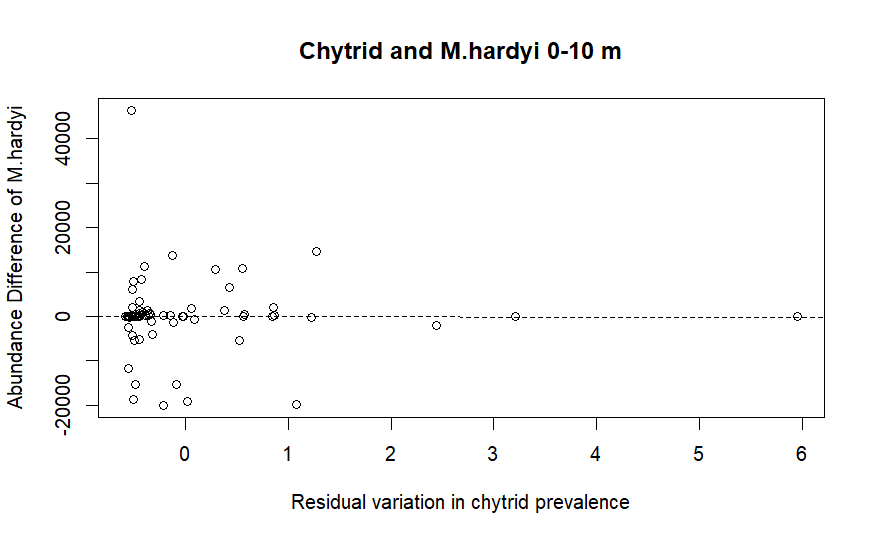

```r
plot(data10m$diff_density_M ~ resi_M10m,
     main = "Chytrid and M.hardyi 0-10 m",
     xlab = "Residual variation in chytrid prevalence",
     ylab = "Abundance Difference of M.hardyi"
     )
abline(lm_sub_model_M10m, lty = "dashed")
```

#### [6.1.2] For S.dorsidentiferum

The regression model of chytrid prevalence on other explanatory variables

```r
sub_model_S10m <- gls(model = prevalence_S ~ water_temp + DIN + PO4, data = data10m, correlation = corARMA(p = 2))
resi_S10m <- residuals(sub_model_S10m)
```

Plot of chytrid prevalence vs the model residual

```r
summary(lm_sub_model_S10m <- lm(data10m$density_S ~ resi_S10m))
```

```
Call:
lm(formula = data10m$density_S ~ resi_S10m)

Residuals:
    Min      1Q  Median      3Q     Max
-1503.0 -1310.1 -1099.9  -396.5 13924.4

Coefficients:
            Estimate Std. Error t value Pr(>|t|)
(Intercept)   1322.8      336.9   3.927 0.000204 ***
resi_S10m     -128.3      370.6  -0.346 0.730223
---
Signif. codes:  0 ‘***’ 0.001 ‘**’ 0.01 ‘*’ 0.05 ‘.’ 0.1 ‘ ’ 1

Residual standard error: 2818 on 68 degrees of freedom
Multiple R-squared:  0.00176,   Adjusted R-squared:  -0.01292
F-statistic: 0.1199 on 1 and 68 DF,  p-value: 0.7302
```

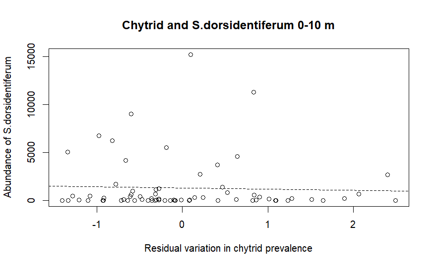

```r
plot(data10m$density_S ~ resi_S10m,
     main = "Chytrid and S.dorsidentiferum 0-10 m",
     xlab = "Residual variation in chytrid prevalence",
     ylab = "Abundance of S.dorsidentiferum"
     )
abline(lm_sub_model_S10m, lty = "dashed")
```

### [6.2] For the data @ 10-20m

#### [6.2.1] For M.hardyi

The regression model of chytrid prevalence on other explanatory variables

```r
sub_model_M20m <- lm(prevalence_M ~ water_temp + DIN + PO4, data = data20m)
resi_M20m <- residuals(sub_model_M20m)
```

Plot of chytrid prevalence vs the model residual

```r
summary(lm_sub_model_M20m <- lm(data20m$diff_density_M ~ resi_M20m))
```

```
Call:
lm(formula = data20m$diff_density_M ~ resi_M20m)

Residuals:
   Min     1Q Median     3Q    Max
-18092   -508    -24    552  36060

Coefficients:
            Estimate Std. Error t value Pr(>|t|)
(Intercept)    1.929    752.008   0.003    0.998
resi_M20m    -61.348    781.918  -0.078    0.938

Residual standard error: 6292 on 68 degrees of freedom
Multiple R-squared:  9.052e-05, Adjusted R-squared:  -0.01461
F-statistic: 0.006156 on 1 and 68 DF,  p-value: 0.9377
```

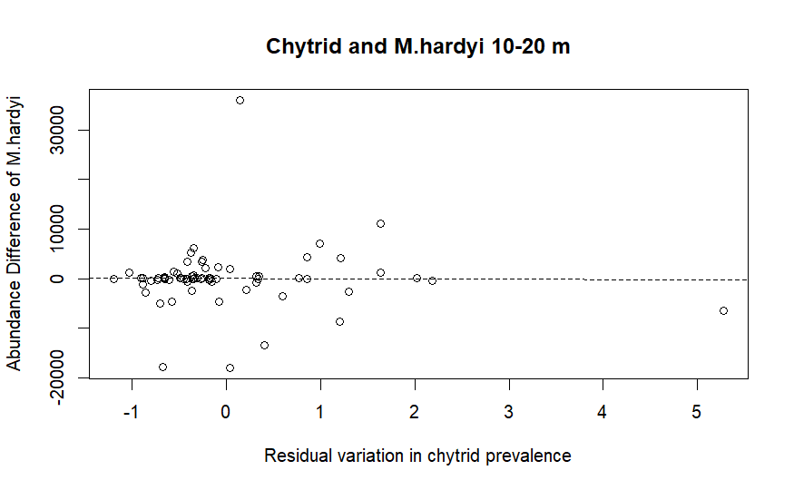

```r
plot(data20m$diff_density_M ~ resi_M20m,
     main = "Chytrid and M.hardyi 10-20 m",
     xlab = "Residual variation in chytrid prevalence",
     ylab = "Abundance Difference of M.hardyi"
     )
abline(lm_sub_model_M20m, lty = "dashed")
```

#### [6.2.2] For S.dorsidentiferum

The regression model of chytrid prevalence on other explanatory variables

```r
sub_model_S20m <- gls(model = prevalence_S ~ water_temp + DIN + PO4, data = data20m, correlation = corARMA(p = 2))
resi_S20m <- residuals(sub_model_S20m)
```

Plot of chytrid prevalence vs the model residual

```r
summary(lm_sub_model_S20m <- lm(data20m$density_S ~ resi_S20m))
```

```
Call:
lm(formula = data20m$density_S ~ resi_S20m)

Residuals:
    Min      1Q  Median      3Q     Max
-269.50 -213.00 -187.99  -10.47 2516.05

Coefficients:
            Estimate Std. Error t value Pr(>|t|)
(Intercept)   218.95      53.92   4.061 0.000129 ***
resi_S20m      24.75      58.14   0.426 0.671658
---
Signif. codes:  0 ‘***’ 0.001 ‘**’ 0.01 ‘*’ 0.05 ‘.’ 0.1 ‘ ’ 1

Residual standard error: 451.1 on 68 degrees of freedom
Multiple R-squared:  0.002658,  Adjusted R-squared:  -0.01201
F-statistic: 0.1812 on 1 and 68 DF,  p-value: 0.6717
```

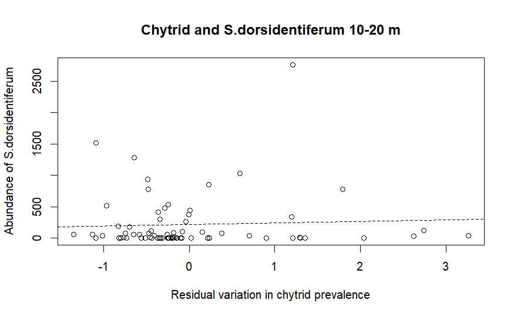

```r
plot(data20m$density_S ~ resi_S20m,
     main = "Chytrid and S.dorsidentiferum 10-20 m",
     xlab = "Residual variation in chytrid prevalence",
     ylab = "Abundance of S.dorsidentiferum")
abline(lm_sub_model_S20m, lty = "dashed")
```

### [6.3] For the data @ 20-40m

#### [6.3.1] For M.hardyi

The regression model of chytrid prevalence on other explanatory variables

```r
sub_model_M40m <- lm(prevalence_M ~ water_temp + DIN + PO4, data = data40m)
resi_M40m <- residuals(sub_model_M40m)
```

Plot of chytrid prevalence vs the model residual

```r
summary(lm_sub_model_M40m <- lm(data40m$diff_density_M ~ resi_M40m))
```

```
Call:
lm(formula = data40m$diff_density_M ~ resi_M40m)

Residuals:
    Min      1Q  Median      3Q     Max
-9925.5  -266.4   -97.8   431.0 14827.2

Coefficients:
             Estimate Std. Error t value Pr(>|t|)
(Intercept)    0.3429   340.1716   0.001    0.999
resi_M40m   -307.7912   344.4860  -0.893    0.375

Residual standard error: 2846 on 68 degrees of freedom
Multiple R-squared:  0.0116,    Adjusted R-squared:  -0.002932
F-statistic: 0.7983 on 1 and 68 DF,  p-value: 0.3748
```

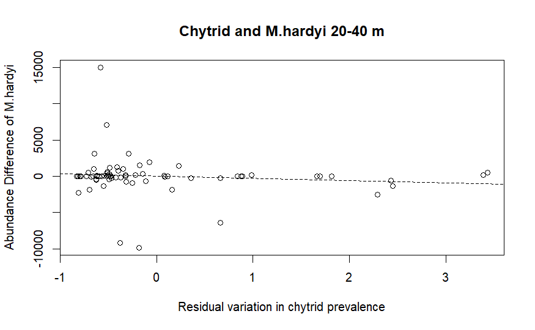

```r
plot(data40m$diff_density_M ~ resi_M40m,
     main = "Chytrid and M.hardyi 20-40 m",
     xlab = "Residual variation in chytrid prevalence",
     ylab = "Abundance Difference of M.hardyi"
     )
abline(lm_sub_model_M40m, lty = "dashed")
```

#### [6.3.2] For S.dorsidentiferum

The regression model of chytrid prevalence on other explanatory variables

```r
sub_model_S40m <- lm(prevalence_S ~ water_temp + DIN + PO4, data = data40m)
resi_S40m <- residuals(sub_model_S40m)
```

Plot of chytrid prevalence vs the model residual

```r
summary(lm_sub_model_S40m <- lm(data40m$diff_density_S ~ resi_S40m))
```

```
Call:
lm(formula = data40m$diff_density_S ~ resi_S40m)

Residuals:
    Min      1Q  Median      3Q     Max
-761.89  -31.96   -6.87   43.62  577.28

Coefficients:
              Estimate Std. Error t value Pr(>|t|)
(Intercept) -1.204e-15  1.874e+01   0.000   1.0000
resi_S40m   -4.273e+01  1.972e+01  -2.166   0.0338 *
---
Signif. codes:  0 ‘***’ 0.001 ‘**’ 0.01 ‘*’ 0.05 ‘.’ 0.1 ‘ ’ 1

Residual standard error: 156.8 on 68 degrees of freedom
Multiple R-squared:  0.06455,   Adjusted R-squared:  0.05079
F-statistic: 4.692 on 1 and 68 DF,  p-value: 0.03381
```

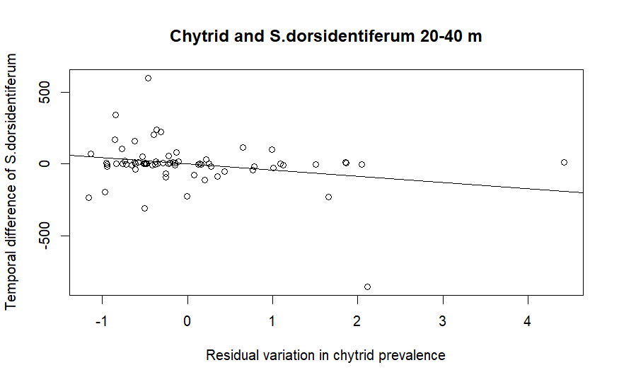

```r
plot(data40m$diff_density_S ~ resi_S40m,
     main = "Chytrid and S.dorsidentiferum 20-40 m",
     xlab = "Residual variation in chytrid prevalence",
     ylab = "Temporal difference of S.dorsidentiferum")
abline(lm_sub_model_S40m)
```